# Empirical Bayes Disease Mapping in Pennsylvania

Lung cancer: global and local smoothing

Author

Eric M. Delmelle · Lehigh University · BSTA 374

## Today’s goals

We will use **lung cancer counts in Pennsylvania’s 67 counties (2002)**. You already know how to calculate a standardized incidence ratio (SIR). Today we focus on *smoothing* those SIRs with two methods: **global empirical Bayes (EB)** and **local empirical Bayes (local EB)**.

By the end, you should be able to:

1. explain why a county with few expected cases can have an extreme SIR;
2. explain the **weighted average** used by empirical Bayes;
3. distinguish borrowing from the **state** and borrowing from **neighbors**;
4. interpret the three maps: raw SIR, global EB, and local EB.

**Note**

Install the required packages once. The lung cancer data are already included in `SpatialEpi`—no shapefile or CSV download is needed.

```r
install.packages(c("sf", "dplyr", "tidyr", "ggplot2", "spdep", "SpatialEpi"))
```

```r
library(sf)
library(dplyr)
library(tidyr)
library(ggplot2)
library(spdep)
library(SpatialEpi)
```

# 1. A quick reminder: raw SIRs

## Prepare the lung cancer data

The dataset has **16 records per county**, corresponding to combinations of race, sex, and age. To obtain an age-, sex-, and race-standardized SIR, we first calculate Pennsylvania’s rate within each group (stratum).

$$E_i = \sum_s P_{is} r_s, \qquad
\mathrm{SIR}_i = \frac{O_i}{E_i}.$$

Here, $O_i$ = observed cases, $E_i$ = expected cases, $P_{is}$ = county population in stratum $s$, and $r_s$ = Pennsylvania rate in that stratum. **SIR = 1** means the observed count equals the expected count.

```r
data("pennLC_sf", package = "SpatialEpi")

# The original sf object contains 16 records per county.
d <- pennLC_sf |>
  st_drop_geometry()

# Reference rate for every race / sex / age stratum.
reference <- d |>
  group_by(race, gender, age) |>
  summarise(rate = sum(cases) / sum(population), .groups = "drop")

# One record per county: observed cases, expected cases, and SIR.
county_data <- d |>
  left_join(reference, by = c("race", "gender", "age")) |>
  group_by(county) |>
  summarise(O = sum(cases), E = sum(population * rate), .groups = "drop") |>
  mutate(county = as.character(county), SIR = O / E)

# Keep one polygon per county and attach our calculations.
pa <- pennLC_sf |>
  group_by(county) |>
  slice(1) |>
  ungroup() |>
  select(county) |>
  mutate(county = as.character(county)) |>
  left_join(county_data, by = "county") |>
  arrange(county)

stopifnot(nrow(pa) == 67, !anyNA(pa$O), all(pa$E > 0))

pa |>
  st_drop_geometry() |>
  summarise(counties = n(), observed_cases = sum(O),
            expected_cases = round(sum(E)))
```

```
# A tibble: 1 × 3
  counties observed_cases expected_cases
     <int>          <int>          <dbl>
1       67          10279          10279
```

## Look at the raw SIRs

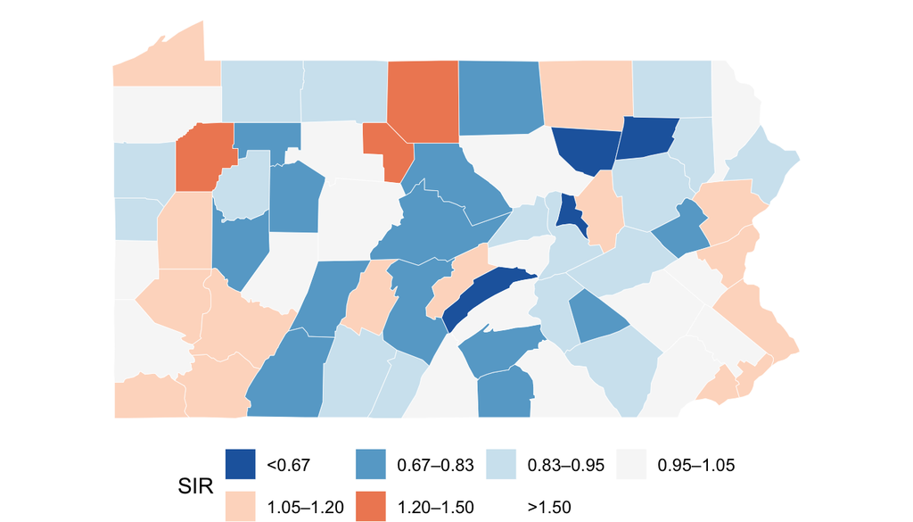

Figure 1: Raw lung cancer SIRs in Pennsylvania counties, 2002.

```r
# Fixed breaks will be reused for all three maps.
risk_breaks <- c(0, 0.67, 0.83, 0.95, 1.05, 1.20, 1.50, Inf)
risk_labels <- c("<0.67", "0.67–0.83", "0.83–0.95", "0.95–1.05",
                 "1.05–1.20", "1.20–1.50", ">1.50")

risk_class <- function(x) {
  cut(x, breaks = risk_breaks, labels = risk_labels,
      include.lowest = TRUE)
}

ggplot(pa) +
  geom_sf(aes(fill = risk_class(SIR)), colour = "white", linewidth = 0.15) +
  scale_fill_brewer(palette = "RdBu", direction = -1,
                    drop = FALSE, name = "SIR") +
  theme_void(base_size = 12) +
  theme(legend.position = "bottom") +
  guides(fill = guide_legend(nrow = 2, byrow = TRUE))
```

Consider the counties with the lowest and highest SIRs. Look not only at the SIR but also at **E**, the expected number of cases.

```r
county_data |>
  arrange(SIR) |>
  slice(c(1:3, (n() - 2):n())) |>
  mutate(E = round(E, 1), SIR = round(SIR, 2))
```

```
# A tibble: 6 × 4
  county       O     E   SIR
  <chr>    <int> <dbl> <dbl>
1 juniata      6  18.7  0.32
2 sullivan     3   7.4  0.4
3 montour      8  16.1  0.5
4 cameron      8   5.9  1.35
5 venango     70  51.1  1.37
6 potter      22  16    1.37
```

An SIR can change dramatically when a county has only a small number of expected cases. **Empirical Bayes reduces the influence of such extreme raw values.**

# 2. Global empirical Bayes: borrow from Pennsylvania

## One simple formula

A global empirical Bayes estimate is a weighted average of the county’s raw SIR and the overall Pennsylvania reference:

$$\widehat\theta_i = w_i\,\mathrm{SIR}_i + (1-w_i)\,m,
\qquad
w_i = \frac{a}{a + m/E_i}.$$

- $m$: overall reference (approximately **1** because the expected counts were calculated using Pennsylvania rates);
- $a$: estimated between-county variation;
- $w_i$: weight placed on the county’s own SIR, between 0 and 1.

When $E_i$ is small, $w_i$ tends to be smaller and the county’s SIR moves more toward the statewide reference. The data determine $a$ and $m$; we do not choose arbitrary weights.

## Run global empirical Bayes

```r
# Counts (O) and expected cases (E) give smoothed relative risks.
eb_global <- EBest(pa$O, pa$E, family = "poisson")
pa$RR_global <- eb_global$estmm

# In the Poisson implementation, parameters are called 'a' and 'b'.
# 'b' is the overall reference m; 'a' is between-county variation.
par_global <- attr(eb_global, "parameters")
a_global <- par_global$a
m_global <- par_global$b

# Weight on the county's observed SIR.
pa$w_global <- a_global / (a_global + m_global / pa$E)

# Confirm the weighted-average formula reproduces EBest() results.
stopifnot(isTRUE(all.equal(
  unname(pa$RR_global),
  unname(pa$w_global * pa$SIR + (1 - pa$w_global) * m_global),
  tolerance = 1e-7
)))

c(state_reference = m_global, between_county_variation = a_global)
```

```
         state_reference between_county_variation
              1.00000000               0.00926715
```

```r
pa |>
  st_drop_geometry() |>
  filter(county %in% c("sullivan", "potter", "venango",
                       "lehigh", "philadelphia")) |>
  arrange(E) |>
  transmute(county, O, expected = round(E, 1),
            raw_SIR = round(SIR, 2),
            weight = round(w_global, 2),
            global_EB = round(RR_global, 2))
```

```
# A tibble: 5 × 6
  county           O expected raw_SIR weight global_EB
  <chr>        <int>    <dbl>   <dbl>  <dbl>     <dbl>
1 sullivan         3      7.4    0.4    0.06      0.96
2 potter          22     16      1.37   0.13      1.05
3 venango         70     51.1    1.37   0.32      1.12
4 lehigh         252    260.     0.97   0.71      0.98
5 philadelphia  1415   1219.     1.16   0.92      1.15
```

A weight near **1** preserves most of the original SIR. A weight near **0** means more borrowing from the statewide reference.

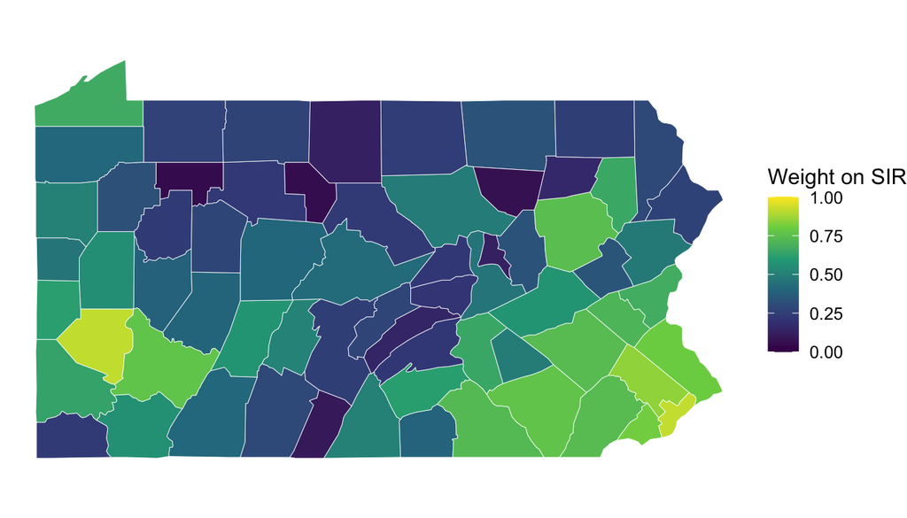

Figure 2: Weight on the original county SIR in the global EB estimate.

```r
ggplot(pa) +
  geom_sf(aes(fill = w_global), colour = "white", linewidth = 0.15) +
  scale_fill_viridis_c(limits = c(0, 1), name = "Weight on SIR") +
  theme_void(base_size = 12)
```

**Question:** Which counties retain more of their own SIR—the large or small counties? Why?

# 3. Local empirical Bayes: borrow from neighbors

## Define the neighbors

Instead of one statewide reference, local EB uses a **different neighborhood reference for each county**. We begin with **queen contiguity**: counties are neighbors when they share part of a boundary or a corner.

```r
nb <- poly2nb(pa, queen = TRUE)
stopifnot(length(nb) == nrow(pa), all(card(nb) > 0))

# Inspect the neighbors of Lehigh County.
i <- match("lehigh", pa$county)
pa$county[nb[[i]]]
```

```
[1] "berks"       "bucks"       "carbon"      "montgomery"  "northampton"
[6] "schuylkill"
```

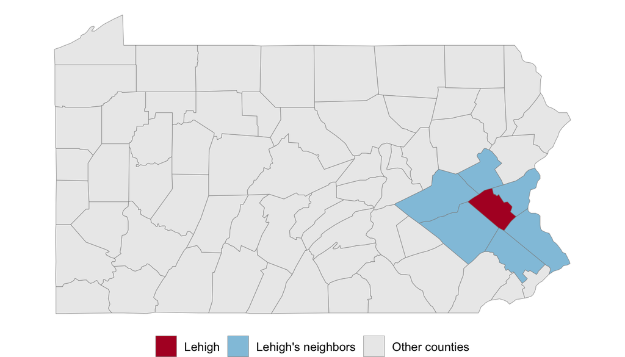

Figure 3: Lehigh County and its queen-contiguity neighbors.

```r
pa$neighbor_group <- "Other counties"
pa$neighbor_group[nb[[i]]] <- "Lehigh's neighbors"
pa$neighbor_group[i] <- "Lehigh"

ggplot(pa) +
  geom_sf(aes(fill = neighbor_group), colour = "grey55", linewidth = 0.15) +
  scale_fill_manual(values = c("Lehigh" = "#b2182b",
                               "Lehigh's neighbors" = "#92c5de",
                               "Other counties" = "grey92"),
                    name = NULL) +
  theme_void(base_size = 12) +
  theme(legend.position = "bottom")
```

## Run local empirical Bayes

```r
# Local EB uses neighbors' counts and expected cases.
eb_local <- EBlocal(pa$O, pa$E, nb,
                    zero.policy = FALSE, spChk = FALSE)
pa$RR_local <- eb_local$est

# Each county has its own local reference and its own smoothing weight.
par_local <- attr(eb_local, "parameters")
pa$m_local <- par_local$m
pa$w_local <- par_local$a /
  (par_local$a + par_local$m / pa$E)

stopifnot(all(is.finite(pa$RR_local)))
```

Local EB follows the same idea as global EB, but replaces the statewide reference with a **neighborhood reference**. For this function, that reference is calculated from the neighboring counties (not the focal county). The local reference and weight may differ substantially from place to place.

```r
pa |>
  st_drop_geometry() |>
  filter(county %in% c("sullivan", "potter", "venango",
                       "lehigh", "philadelphia")) |>
  arrange(E) |>
  transmute(county, expected = round(E, 1),
            raw_SIR = round(SIR, 2),
            neighbor_reference = round(m_local, 2),
            local_weight = round(w_local, 2),
            local_EB = round(RR_local, 2))
```

```
# A tibble: 5 × 6
  county       expected raw_SIR neighbor_reference local_weight local_EB
  <chr>           <dbl>   <dbl>              <dbl>        <dbl>    <dbl>
1 sullivan          7.4    0.4                0.95         0.01     0.94
2 potter           16      1.37               0.94         0.06     0.97
3 venango          51.1    1.37               1.04         0.32     1.15
4 lehigh          260.     0.97               1            0.21     0.99
5 philadelphia   1219.     1.16               1.09         0.72     1.14
```

For example, Lehigh County has the following values:

```r
pa |>
  st_drop_geometry() |>
  filter(county == "lehigh") |>
  transmute(county,
            SIR = round(SIR, 2),
            state_reference = round(m_global, 2),
            neighbor_reference = round(m_local, 2),
            global_EB = round(RR_global, 2),
            local_EB = round(RR_local, 2))
```

```
# A tibble: 1 × 6
  county   SIR state_reference neighbor_reference global_EB local_EB
  <chr>  <dbl>           <dbl>              <dbl>     <dbl>    <dbl>
1 lehigh  0.97               1                  1      0.98     0.99
```

**Question:** Why is the local EB estimate not necessarily closer to 1 than the raw SIR? Think about the risk in the neighboring counties.

# 4. Compare all three maps

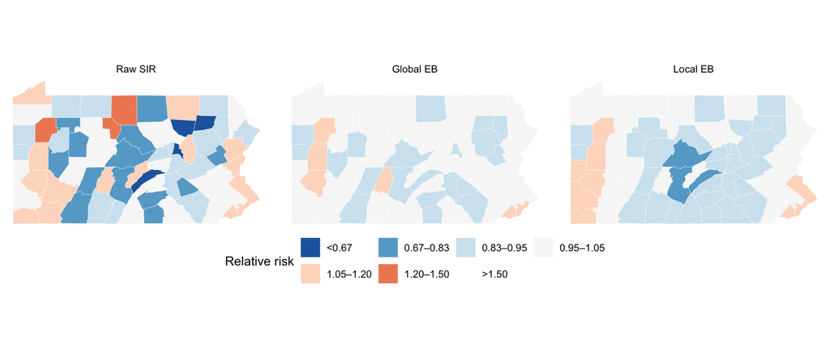

Figure 4: Raw SIR, global EB and local EB. Identical map classes allow direct comparison.

```r
pa |>
  select(county, SIR, RR_global, RR_local) |>
  pivot_longer(cols = c(SIR, RR_global, RR_local),
               names_to = "method", values_to = "risk") |>
  mutate(method = factor(method,
                         levels = c("SIR", "RR_global", "RR_local"),
                         labels = c("Raw SIR", "Global EB", "Local EB"))) |>
  ggplot() +
  geom_sf(aes(fill = risk_class(risk)), colour = "white", linewidth = 0.1) +
  facet_wrap(~ method, nrow = 1) +
  scale_fill_brewer(palette = "RdBu", direction = -1,
                    drop = FALSE, name = "Relative risk") +
  theme_void(base_size = 11) +
  theme(legend.position = "bottom") +
  guides(fill = guide_legend(nrow = 2, byrow = TRUE))
```

Let’s also look at the counties whose estimated risk changes the most.

```r
pa |>
  st_drop_geometry() |>
  mutate(change_global = abs(RR_global - SIR),
         change_local = abs(RR_local - SIR)) |>
  arrange(desc(change_global)) |>
  slice_head(n = 8) |>
  transmute(county, expected = round(E),
            SIR = round(SIR, 2),
            global_EB = round(RR_global, 2),
            local_EB = round(RR_local, 2),
            global_change = round(change_global, 2))
```

```
# A tibble: 8 × 6
  county   expected   SIR global_EB local_EB global_change
  <chr>       <dbl> <dbl>     <dbl>    <dbl>         <dbl>
1 juniata        19  0.32      0.9      0.73          0.58
2 sullivan        7  0.4       0.96     0.94          0.56
3 montour        16  0.5       0.93     0.92          0.44
4 cameron         6  1.35      1.02     0.98          0.33
5 potter         16  1.37      1.05     0.97          0.33
6 wyoming        21  0.67      0.95     0.91          0.28
7 venango        51  1.37      1.12     1.15          0.25
8 forest          5  0.74      0.99     0.98          0.25
```

**TipRemember**

**Global EB:** each county borrows from the same Pennsylvania reference.

**Local EB:** each county borrows from its own surrounding neighbors.

Both methods produce **smoothed relative risks**, but they need not give the same result, and local smoothing is not automatically better than global smoothing.

# 5. In-class exercise: 15 minutes

Work in pairs. Use your maps and the R output, and answer in plain English.

1. **Raw versus global EB (5 minutes).** Choose a county with a high raw SIR and relatively few expected cases. Report its $O$, $E$, SIR and global EB estimate. Did its risk estimate move toward 1? Explain why.
2. **Global versus local EB (5 minutes).** For **Lehigh County**, report the raw SIR, global EB, local EB, and the local neighborhood reference. In one or two sentences, explain why the two smoothed estimates differ.
3. **Think spatially (5 minutes).** Compare the three maps. Identify one area whose appearance changes noticeably after smoothing. Which reference—state or neighbors—would be more appropriate for the question you want to ask?

# Key takeaways

- **SIR = O / E:** compares observed to expected cases.
- **Global empirical Bayes:** a weighted average of the county SIR and a statewide reference.
- **Local empirical Bayes:** a weighted average of the county SIR and a neighborhood reference.
- **Smoothing weights:** determined by the data; counties with smaller expected counts often borrow more.
- **Geography matters:** changing the definition of neighbors can change a local EB map.

# References

- Marshall, R. J. (1991). Mapping disease and mortality rates using empirical Bayes estimators. *Applied Statistics*, 40(2), 283–294.
- Clayton, D., & Kaldor, J. (1987). Empirical Bayes estimates of age-standardized relative risks for use in disease mapping. *Biometrics*, 43(3), 671–681.
- Dataset: `SpatialEpi::pennLC_sf` (Pennsylvania lung cancer, 2002).
- R documentation: [spdep global EB](https://r-spatial.github.io/spdep/reference/EBest.html) and [spdep local EB](https://r-spatial.github.io/spdep/reference/EBlocal.html).